# Statistical Inference Course Project Part 2

### Intoduction

In this paper we study the response is the length of odontoblasts (teeth) in each of 10 guinea pigs to two delivery methods (orange juice or ascorbic acid).

First of all, load dataset and compute quick summary.

```r
data(ToothGrowth)
summary(ToothGrowth)
```

```
##       len       supp         dose
##  Min.   : 4.2   OJ:30   Min.   :0.50
##  1st Qu.:13.1   VC:30   1st Qu.:0.50
##  Median :19.2           Median :1.00
##  Mean   :18.8           Mean   :1.17
##  3rd Qu.:25.3           3rd Qu.:2.00
##  Max.   :33.9           Max.   :2.00
```

### Analythis

We can suppose form Appendix, Fig. 1 that with bigger dose of vitamin C tooth grow faster. Another hypothesis that supplement type OJ also leads to faster tooth grows.

First let’s check hypothesis about supplement type with independent t-test:

```
##
##  Welch Two Sample t-test
##
## data:  len by supp
## t = 1.915, df = 55.31, p-value = 0.06063
## alternative hypothesis: true difference in means is not equal to 0
## 95 percent confidence interval:
##  -0.171  7.571
## sample estimates:
## mean in group OJ mean in group VC
##            20.66            16.96
```

P-value slightly greater than 0.05, 95% confidence interval includes zero, so at 95% level there is no difference in tooth length between different supplement type. If we will consider this problem with 90% level there is a difference exists in tooth length.

Now we check difference between doses. It will be better to use ANOVA or regression but in this assignment we are limited to t-test.

```r
t.test(len ~ dose,data=ToothGrowth,subset = dose %in% c(0.5,1)) # test  between dose 0.5 and 1
```

```
##
##  Welch Two Sample t-test
##
## data:  len by dose
## t = -6.477, df = 37.99, p-value = 1.268e-07
## alternative hypothesis: true difference in means is not equal to 0
## 95 percent confidence interval:
##  -11.984  -6.276
## sample estimates:
## mean in group 0.5   mean in group 1
##             10.61             19.73
```

```r
t.test(len ~ dose,data=ToothGrowth,subset = dose %in% c(1,2)) # test  between dose 1 and 2
```

```
##
##  Welch Two Sample t-test
##
## data:  len by dose
## t = -4.901, df = 37.1, p-value = 1.906e-05
## alternative hypothesis: true difference in means is not equal to 0
## 95 percent confidence interval:
##  -8.996 -3.734
## sample estimates:
## mean in group 1 mean in group 2
##           19.73           26.10
```

```r
t.test(len ~ dose,data=ToothGrowth,subset = dose %in% c(0.5,2)) # test  between dose 0.5 and 2
```

```
##
##  Welch Two Sample t-test
##
## data:  len by dose
## t = -11.8, df = 36.88, p-value = 4.398e-14
## alternative hypothesis: true difference in means is not equal to 0
## 95 percent confidence interval:
##  -18.16 -12.83
## sample estimates:
## mean in group 0.5   mean in group 2
##             10.61             26.10
```

P-value is far less than 0.05 value so there is significant differences between tooth lens in groups with different doses. P-value is so small that even with multiple comparisons adjustments (such as Bonferroni adjustment) there will be significant difference.

### Conclusion

There is significant difference in the tooth length between groups with different doses of vitamin C. But supplement type doesn’t has strong influence on tooth growth.

### Appendix

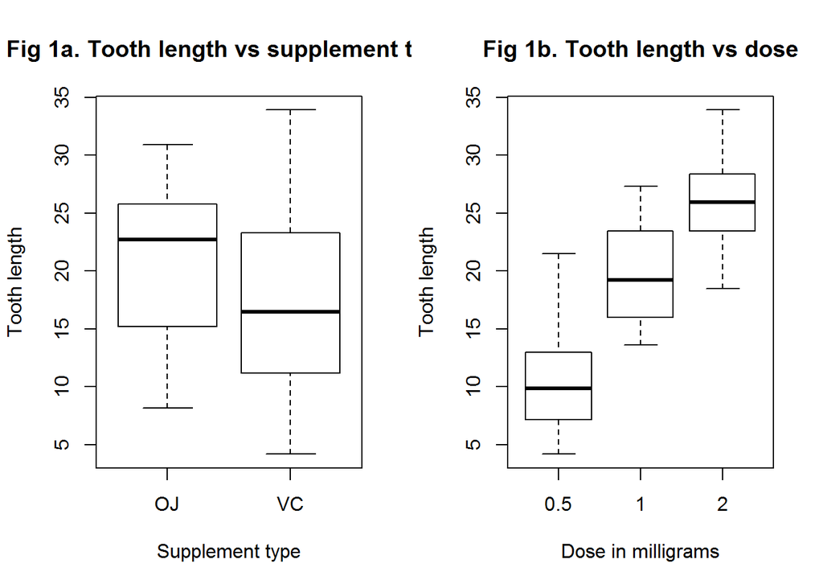

```r
par(mfrow=c(1,2))
boxplot(len ~ supp, data=ToothGrowth,xlab="Supplement type", ylab="Tooth length", main="Fig 1a. Tooth length vs supplement type")
boxplot(len ~ dose, data=ToothGrowth,xlab="Dose in milligrams", ylab="Tooth length", main="Fig 1b. Tooth length vs dose")
```